# Setup environment

```python
!pip install gensim emoji nltk tqdm seaborn torch torchsummary -q
```

```python
import pandas as pd
import torch
from torch import nn
from torch.utils.data import DataLoader, Dataset

import gensim

from sklearn.model_selection import train_test_split
import sklearn.metrics as metrics

import matplotlib.pyplot as plt
import seaborn as sns
import numpy as np
from tqdm import tqdm
import gc
import os

import ssl
ssl._create_default_https_context = ssl._create_unverified_context
```

# Config

## Model training config

```python
LEARNING_RATE = 4e-4
WEIGHT_DECAY = 1e-2
BATCH_SIZE = 64
EPOCHS = 15

SEQUENCE_LEN = 64
SEQUENCE_LEN2 = 196
CNN_FILTERS = 64
```

```python
DEVICE = torch.device("cuda" if torch.cuda.is_available() else "cpu")
```

# Data Preparation

## Load Data

```python
# TODO: Load read and load the data here
PATH = 'D:/Universite/Term 6/Artificial Intelligence/CAs/CA5/twitter-suicidal-data.csv'
df = pd.read_csv(PATH)
```

## Data Preprocessing

```python
import nltk
import emoji
import re

nltk.download(["stopwords", "punkt", "wordnet", "averaged_perceptron_tagger"])
```

```
True
```

```python
from nltk.tokenize import word_tokenize
from nltk.stem import WordNetLemmatizer

def lowercase(text):
    return text.lower()

def remove_punctuations(text):
    # def remove_punctuations(text):
    # Define the regex pattern to exclude '@' and emojis
    pattern = r'[^\w\s@' +  u'\U0001F600-\U0001F64F' + u'\U0001F300-\U0001F5FF' + u'\U0001F680-\U0001F6FF' + u'\U0001F1E0-\U0001F1FF' + u'\U00002500-\U00002BEF' +  u'\U00002702-\U000027B0' +']'
    text = re.sub(pattern, '', text)  # Remove punctuations excluding '@' and emojis
    return text

def remove_numbers(text):
    return re.sub(r'\d+', '', text)

def remove_urls(text):
    return re.sub(r'http\S+|www.\S+', '', text)

def remove_usernames(text):
    return re.sub(r'@\w+', '', text)

def remove_extra_spaces(text):
    return re.sub(r'\s+', ' ', text).strip() #watch out for the strip method

def convert_emoji_to_text(text):
    emojiless_text = re.sub(r'[^\w\s]', ' ', text)
    return emojiless_text

def remove_non_words(text):
    # return re.sub(r'\W+', '', text)
    return re.sub(r'[^\w\s]', '', text)



def lemmatization_tokenization(text):
    tokens = word_tokenize(text)
    lemmatizer = WordNetLemmatizer()
    # Get POS tags for each token and convert to WordNet POS tag
    pos_tags = nltk.pos_tag(tokens)
    lemmas = [lemmatizer.lemmatize(token, nltk_pos_tagger(pos_tag)) for token, pos_tag in pos_tags]
    return lemmas

def remove_stopwords(tokens):
    stopwords = nltk.corpus.stopwords.words("english")
    filtered_text = [word for word in tokens if word not in stopwords]
    return filtered_text


def nltk_pos_tagger(nltk_tag): #detects part of speech
    if nltk_tag.startswith('J'):
        return 'a'
    elif nltk_tag.startswith('V'):
        return 'v'
    elif nltk_tag.startswith('N'):
        return 'n'
    elif nltk_tag.startswith('R'):
        return 'r'
    else:
        return 'n'

def preprocess_data(text: str):
    lowered_text = lowercase(text)
    p_removed_text = remove_punctuations(lowered_text)
    n_removed_text = remove_numbers(p_removed_text)
    urls_removed_text = remove_urls(n_removed_text)
    usernames_removed_text = remove_usernames(urls_removed_text)
    emoji_removed_text = convert_emoji_to_text(usernames_removed_text)
    extra_spaces_removed_text = remove_extra_spaces(emoji_removed_text)
    nonwords_removed_text = remove_non_words(extra_spaces_removed_text)
    tokens = lemmatization_tokenization(nonwords_removed_text)
    tokenized_text = remove_stopwords(tokens)
    return tokenized_text
```

## Phase 0 Questions:

### 1. Why do we convert the works to lowercase?

Converting words to lowercase in word preprocessing is a common practice in natural language processing (NLP) for several reasons:

1. Normalization: By converting all words to lowercase, we ensure that words are consistent and standardized throughout the text. This helps in reducing the vocabulary size by merging words that differ only in their casing (e.g., "Hello" and "hello" are treated as the same word).
2. Tokenization: Lowercasing words makes it easier to tokenize the text into individual words. Tokenization is a fundamental preprocessing step in NLP where text is split into smaller units (words, phrases, or symbols) to analyze and process them.
3. Consistency in Text Analysis: Lowercasing words ensures that text analysis methods such as counting word frequencies or identifying common words are not affected by the casing variations of the words.
4. Improved Model Performance: A model that is case-insensitive can benefit from lowercasing words as it reduces the complexity of the input data and improves generalization by treating words with different cases as the same word.
5. Avoiding Duplication: Lowercasing words helps in avoiding duplication of words in the vocabulary for words that differ only in casing. This helps in reducing the model's training time and memory usage.

Overall, converting words to lowercase in word preprocessing is a standard practice that facilitates text processing, improves model performance, and ensures consistency in NLP tasks.

### 2. Why do we omit the numeric data? Tell the pros and cons of this method

Omitting numeric data in some natural language processing (NLP) tasks is a common approach because the presence of numeric data may introduce noise or unnecessary complexity to the textual analysis. Here are some pros and cons of omitting numeric data in NLP tasks:

Pros of Omitting Numeric Data:

1. Improved Text Processing: Omitting numeric data simplifies text processing and analysis by focusing on textual content only. This can lead to more efficient text preprocessing steps such as tokenization, stemming, and vectorization.
2. Reduced Noise: Numeric data can sometimes be noisy and irrelevant to certain NLP tasks. By removing numeric values, you may improve the accuracy and reliability of the analysis focused on the textual content.
3. Enhanced Model Performance: In some NLP tasks like sentiment analysis or text classification, including numeric data alongside text may complicate the model training process. Omitting numeric data can lead to more streamlined and optimized models.

Cons of Omitting Numeric Data:

1. Information Loss: Numeric data may contain valuable information that can be relevant for the NLP task at hand. Omitting numeric data may result in the loss of important context or details that could enhance the understanding of the text.
2. Contextual Relevance: In some cases, numeric data within text can provide context or additional meaning to the textual content. Omitting numeric data completely may overlook this context and potentially impact the performance of certain NLP tasks.
3. Overgeneralization: Omitting numeric data from the analysis may lead to oversimplification of the data, potentially ignoring important patterns or variations that exist within the text along with the numeric information.

Ultimately, the decision to omit numeric data in NLP tasks depends on the specific requirements, objectives, and characteristics of the dataset and the task at hand. It is important to carefully consider the pros and cons and determine whether keeping or omitting numeric data aligns with the goals of the NLP analysis.

### 3. Why haven't we removed the hashtags?

I think that hashtags in social media often point to a keyword of an important thing or feature that is related to our text. That is why they could be od use to us. They can be used to categorize the content of a text in social media, create connections between posts, and express emotions or opinions. While hashtags can provide valuable information and context for understanding the content of social media data, it is important to consider their impact on NLP models. Here are some reasons why we often do not remove hashtags in social media data and the potential impact they can have on our models:

1. Context and Meaning: Hashtags can provide additional context and meaning to the text by highlighting key topics, events, or sentiments discussed in the social media posts. Removing hashtags may result in the loss of valuable information that could help improve the model's understanding of the data.
2. Trend Analysis: Hashtags are commonly used to track trends and topics that are popular or relevant on social media at a given time. Analyzing hashtags alongside text data can help in identifying trending topics, analyzing user sentiment, and understanding the overall social media landscape.
3. Sentiment Analysis: Hashtags are often used to express emotions or opinions related to a specific topic. Including hashtags in sentiment analysis tasks can help capture the sentiment associated with the topic or theme referenced by the hashtags.
4. User Engagement: Hashtags play a significant role in social media engagement and can influence the reach and visibility of posts. Analyzing hashtags along with the text data can provide insights into user engagement, participation in discussions, and overall social media interactions.
5. Feature Engineering: Hashtags can be used as features or input signals in NLP models to improve performance in certain tasks. Extracting and incorporating hashtags as additional features can enhance the model's ability to capture specific topics or themes present in the data.

```python
sample = 'Hello 👋🏼🌎 @parmis http://example.com 123 google at! running  '
tokens = preprocess_data(sample)
print("after:  ")
for token in tokens:
    print(token)
```

```
after:
hello
google
run
```

```
8715    3 30 thinking about sad shit my life is so sad...
6518                      i m still tired wtf boo on that
6430                          hungry type feed to feed me
7502    you brought it up your transgender and i get i...
6818    the temptation was very real today i decided t...
Name: tweet, dtype: object
8715    [think, sad, shit, life, sad, becuse, pepole, ...
6518                              [still, tire, wtf, boo]
6430                            [hungry, type, feed, fee]
7502    [bring, transgender, get, want, support, like,...
6818    [temptation, real, today, decide, bath, today,...
Name: tokens, dtype: object
```

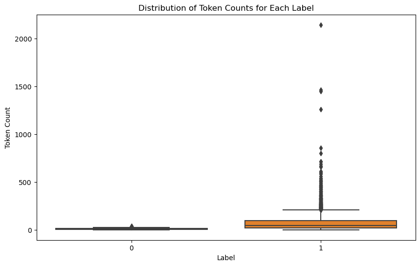

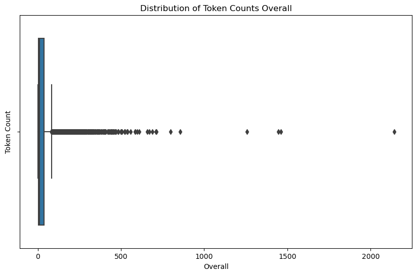

```python
import random
text_column_name = 'tweet'
selected_indices = random.sample(range(len(df)), 5)
selected_rows = df.loc[selected_indices]
print(selected_rows[text_column_name])


df['tokens'] = df[text_column_name].apply(preprocess_data)
df['token_count'] = df['tweet'].apply(lambda x: len(preprocess_data(x)))


print(df['tokens'].loc[selected_indices])


plt.figure(figsize=(10, 6))
sns.boxplot(x='intention', y='token_count', data=df)
plt.title('Distribution of Token Counts for Each Label')
plt.xlabel('Label')
plt.ylabel('Token Count')
plt.show()


plt.figure(figsize=(10, 6))
sns.boxplot(x=df['token_count'])
plt.title('Distribution of Token Counts Overall')
plt.xlabel('Overall')
plt.ylabel('Token Count')
plt.show()
```

# Word2Vec - Word Embedding

```python
# print available word2vec models
import gensim.downloader as api
print("\n".join(api.info()['models'].keys()))
```

```
fasttext-wiki-news-subwords-300
conceptnet-numberbatch-17-06-300
word2vec-ruscorpora-300
word2vec-google-news-300
glove-wiki-gigaword-50
glove-wiki-gigaword-100
glove-wiki-gigaword-200
glove-wiki-gigaword-300
glove-twitter-25
glove-twitter-50
glove-twitter-100
glove-twitter-200
__testing_word2vec-matrix-synopsis
```

```python
W2V_PATH = 'word2vec' # Path to W2V if downloaded
if W2V_PATH is not None and os.path.exists(W2V_PATH):
    print("Loading Word2Vec model...")
    w2v_model = gensim.models.KeyedVectors.load(W2V_PATH, mmap='r')
    print("Word2Vec model is loaded.")
else:
    print("Downloading Word2Vec model...")
    w2v_model = api.load("word2vec-google-news-300")
    print("Word2vec model is downloaded.")
    if W2V_PATH is not None:
      print("\nSaving Word2Vec model...")
      w2v_model.save(W2V_PATH)
      print("Word2Vec model is saved.")
```

```
Loading Word2Vec model...
Word2Vec model is loaded.
```

```python
EMBEDDING_VECTOR_DIM = w2v_model.vector_size
```

# Dataset

```python
import torch
class Twitter(Dataset):
    def __init__(self, dataframe: pd.DataFrame, w2v_model: gensim.models.KeyedVectors, sequence_len: int):
        self.dataframe = dataframe
        self.w2v_model = w2v_model
        self.max_sequence_len = sequence_len
        self.vector_size = w2v_model.vector_size

        self.df_token_col = "tokens"


        self._proc_dataset()

        self.len = len(self.dataframe)

    def __len__(self):
        return self.len

    def __getitem__(self, idx):
        return self.dataframe.iloc[idx]["vector"], self.dataframe.iloc[idx]["intention"]

    def get_vector_size(self):
        return self.vector_size

    def _proc_dataset(self):
        # Preprocess and return tokens list
        self.dataframe[self.df_token_col] = self.dataframe["tweet"].map(preprocess_data)

        # delete samples with empty tokens
        lwz = len(self.dataframe)
        self.dataframe = self.dataframe[self.dataframe[self.df_token_col].map(len) > 0]
        self.dataframe.reset_index(drop=True, inplace=True)
        print(f"Deleted 0-Len Samples: {lwz - len(self.dataframe)}")

        # Add padding
        self.dataframe.loc[:, self.df_token_col] = self.dataframe[self.df_token_col].map(self._pad)

        # Get embedding's vectors
        self.dataframe.loc[:, "vector"] = self.dataframe[self.df_token_col].map(self._get_word_vectors)


    def _get_word_vectors(self, tokens: list) -> torch.tensor:
        vector_list = []
        for token in tokens:
            if isinstance(token, str) and token in self.w2v_model:
                vector_list.append(self.w2v_model[token])
            else:
                vector_list.append(np.zeros(self.vector_size))
        return torch.tensor(vector_list, dtype=torch.float32)



    def _pad(self, tokens: list):
        num_padding = max(0, self.max_sequence_len - len(tokens))
        if len(tokens) > self.max_sequence_len:
            padded_tokens = tokens[:self.max_sequence_len]
        else:
            padding = [''] * num_padding  # Use empty strings for padding before converting to vectors
            padded_tokens =  tokens + padding
        return padded_tokens


    def seq_report(self):
        length_all = self.dataframe[self.df_token_col].map(len).tolist()
        max_length = np.max(length_all)
        print(f"Sequence Length Report")
        print(f":::::MAX  LENGTH:::[{max_length:^5}]")
        print(f":::::MIN  LENGTH:::[{np.min(length_all):^5}]")
        print(f":::::MEAN LENGTH:::[{np.mean(length_all):^5}]")

        all_tokens = set()
        for token_set in self.dataframe[self.df_token_col].tolist():
            all_tokens = all_tokens.union(set(token_set))
        unique_tokens_count = len(all_tokens)
        valid_tokens = sum(1 if token in self.w2v_model else 0 for token in all_tokens)
        print("Sequence Tokenization Report")
        print(f":::::All Unique Tokens:::[{unique_tokens_count:^6}")
        print(f":::::All Valid Tokens:::[{valid_tokens:^6}")
        print(f":::::Valid Tokens:::[{round(100*valid_tokens/unique_tokens_count, 2):^5}%]")

    @staticmethod
    def _to_tensor(tokens: list):
        return torch.tensor(tokens, dtype=torch.float32)
```

### What are the ways to handle words that are not in the dictionary?

When dealing with words that are not present in the word2vec dictionary, there are several strategies you can employ:

1. **Zero Vector**: Use a zero vector for out-of-vocabulary (OOV) words. This is simple but may not be the most effective as it doesn't provide any meaningful information.
2. **Random Vector**: Initialize OOV words with random vectors. The randomness introduces some variety, although the vectors may not be meaningful.
3. **Average Vector**: Use the average vector of all word vectors in the dictionary. This provides a central point in the vector space but may not be representative of the OOV word's semantics.
4. **Subword Information**: Utilize models like FastText that generate vectors for OOV words based on subword information, which can capture the meaning of words by their parts (prefixes, suffixes, etc.).
5. **Custom Embeddings**: Train custom embeddings for your specific dataset, which can include the OOV words encountered in your corpus.
6. **Placeholder Vector**: Assign a unique placeholder vector for all OOV words. This can be useful if you want to treat all OOV words uniformly.
7. **Similarity-based Vector**: Find the most similar words that are in the dictionary and use their vectors or an average of their vectors for the OOV word.
8. **Contextual Embeddings**: Use contextual embedding models like BERT or ELMo that generate word vectors based on the context in which the word appears, thus providing vectors for OOV words based on their usage.

Each method has its pros and cons, and the choice may depend on the specific application and the nature of the dataset you're working with. It's also possible to combine these strategies to handle OOV words more effectively.

# Prepare Data

## Split Data into train-valid

```python
#TODO: Split dataset into train-test split

# X_train, X_test, y_train, y_test = train_test_split(df['tweet'], df['intention'], test_size=0.2, random_state=42)

# Further split the training set into training and validation sets
train_df, valid_df = train_test_split(df, test_size = 0.25, random_state = 42)
```

## Create Datasets

```python
# TODO: create twitter dataset
train_dataset = Twitter(
    dataframe = train_df,
    w2v_model = w2v_model,
    sequence_len = SEQUENCE_LEN
)

valid_dataset = Twitter(
    dataframe = valid_df,
    w2v_model = w2v_model,
    sequence_len = SEQUENCE_LEN
)

print(f"Train dataset length: {len(train_dataset)}")
print(f"Valid dataset length: {len(valid_dataset)}")
```

```
Deleted 0-Len Samples: 22
```

```
Deleted 0-Len Samples: 9
```

```
Train dataset length: 6817
Valid dataset length: 2271
```

# Model and Train

## Utils

```python
import torch
from tqdm import tqdm

@torch.no_grad()
def model_eval(model, loader, loss_function, device: str = 'auto'):
    """Returns test_loss, test_acc"""
    test_loss = 0.0
    correct = 0
    total = 0

    if device == "auto":
        device = torch.device("cuda" if torch.cuda.is_available() else "cpu")

    model = model.to(device)
    model.eval()  # Set the model to evaluation mode
    itr = tqdm(loader, total=len(loader), leave=False)

    for inputs, labels in itr:
        # Move model's inputs and labels to `device`
        inputs, labels = inputs.to(device), labels.to(device)

        # Use model's forward pass to generate outputs
        outputs = model(inputs)

        # Calculate model's loss
        loss = loss_function(outputs, labels)

        # Calculate/update model's accuracy
        _, predicted = torch.max(outputs, 1)
        correct += (predicted == labels).sum().item()
        total += labels.size(0)
        test_loss += loss.item() * inputs.size(0)  # Accumulate the loss

        itr.set_description("(Eval)")
        itr.set_postfix(
            loss = round(loss.item(), 5),
            accuracy = round(correct / total, 5),
        )

    test_loss /= total  # Calculate the average loss
    test_acc = correct / total  # Calculate the overall accuracy

    return test_loss, test_acc
```

```python
import torch
from torch.utils.data import DataLoader
from tqdm import tqdm

def train_model(
        model,
        batch_size,
        loss_function,
        optimizer,
        epochs,
        train_set,
        valid_set,
        device: str = 'auto', ##
):

    if device == "auto":
        device = torch.device("cuda" if torch.cuda.is_available() else "cpu")

    model.to(device)

    train_losses = []
    train_accs = []

    valid_losses = []
    valid_accs = []

    # Create dataloaders from datasets
    train_loader = DataLoader(train_set, batch_size=batch_size, shuffle=True)
    valid_loader = DataLoader(valid_set, batch_size=batch_size, shuffle=False)

    model.to(device)

    for epoch in range(epochs):
        model.train()
        epoch_loss = 0
        epoch_acc = 0
        itr = tqdm(train_loader, total = len(train_loader), leave = False)
        for idx, (inputs, labels) in enumerate(itr, start = 1):
            # Move model's inputs to `device`
            inputs, labels = inputs.to(device), labels.to(device)

            # Use model's forward pass to generate outputs
            outputs = model(inputs)

            # Process model's predictions and calculate/update accuracy
            _, preds = torch.max(outputs, 1)
            acc = (preds == labels).float().mean()
            epoch_acc += acc.item()

            # Calculate model's loss and update epoch's loss
            loss = loss_function(outputs, labels)
            epoch_loss += loss.item()

            # Clear optimizer's state and zero previous gradients
            optimizer.zero_grad()
            # Backward calculated loss
            loss.backward()
            # Step optimizer
            optimizer.step()

            itr.set_description(f"(Training) Epoch [{epoch + 1}/{epochs}]")
            itr.set_postfix(
                loss = round(loss.item(), 5),
                accuracy = round(acc.item(), 5),
            )

        train_losses.append(epoch_loss / len(train_loader))
        train_accs.append(epoch_acc / len(train_loader))

        model.eval()
        valid_loss, valid_acc = model_eval(
            model = model,
            loader = valid_loader,
            loss_function = loss_function,
            device = device
        )

        valid_losses.append(valid_loss)
        valid_accs.append(valid_acc)

    history = {
        "train_loss": train_losses,
        "train_acc": train_accs,
        "valid_loss": valid_losses,
        "valid_acc": valid_accs,
    }
    return history
```

```python
def trend_plot_helper(pobj):
    plt.figure(figsize=(5*len(pobj), 5))
    for idx, (titler, plots) in enumerate(pobj.items(), start=1):
        plt.subplot(1, len(pobj), idx)
        for label, trend in plots:
            plt.plot(range(1, len(trend)+1), trend, label=label)
        yt, xt = titler.split(' - ')
        plt.xlabel(xt)
        plt.ylabel(yt)
        plt.legend()
```

```python
import torch
from torch.utils.data import DataLoader
from tqdm import tqdm
from sklearn import metrics
import matplotlib.pyplot as plt
import seaborn as sns

@torch.no_grad()
def generate_confusion_matrix(model, dataset, device='auto'):
    if device == 'auto':
        device = torch.device("cuda" if torch.cuda.is_available() else "cpu")
    else:
        device = torch.device(device)

    model = model.to(device)

    loader = DataLoader(dataset, batch_size=32, shuffle=False)
    itr = tqdm(loader, leave=False, desc="Generate data")

    # Initialize lists to hold true labels and predictions
    labels = []
    predicted = []

    for inputs, true_labels in itr:
        inputs = inputs.to(device)
        true_labels = true_labels.to(device)

        outputs = model(inputs)
        _, preds = torch.max(outputs, 1)

        labels.extend(true_labels.cpu().numpy())
        predicted.extend(preds.cpu().numpy())

    # Convert lists to numpy arrays
    labels = np.array(labels)
    predicted = np.array(predicted)

    # Generate confusion matrix
    cm = metrics.confusion_matrix(y_true=labels, y_pred=predicted)

    # Plot confusion matrix
    plt.figure(figsize=(10, 10))
    sns.heatmap(cm, cmap='Blues', annot=True, cbar=False, fmt=".0f")
    plt.xlabel('Predicted Label', labelpad=20)
    plt.ylabel('True Label', labelpad=20)
    plt.title('Confusion Matrix', fontsize=30)

    # Calculate evaluation metrics
    recall = metrics.recall_score(y_true=labels, y_pred=predicted, average='macro')
    f1 = metrics.f1_score(y_true=labels, y_pred=predicted, average='macro')
    precision = metrics.precision_score(y_true=labels, y_pred=predicted, average='macro')
    report = metrics.classification_report(y_true=labels, y_pred=predicted)

    return {'recall': recall, 'f1': f1, 'precision': precision, 'report': report}
```

## Model's Network

### Why does kernel size matter in CNN?

Kernel size in Convolutional Neural Networks (CNNs) plays a crucial role in determining the effectiveness and efficiency of the network in learning features from the input data.

1. Receptive field: The size of the kernel determines the area of the input image that each convolutional operation will focus on. A larger kernel size leads to a larger receptive field, allowing the network to capture more spatial information and learn complex patterns in the input data.
2. Feature extraction: Smaller kernel sizes are effective in capturing fine details and local patterns in the input data, while larger kernel sizes are better at capturing global features and overall structure of the input. By using a combination of different kernel sizes in CNNs, the network can effectively learn features at various levels of abstraction.
3. Computational efficiency: Smaller kernel sizes require fewer parameters and computations, making the network more efficient and easier to train. However, larger kernel sizes may be necessary in certain cases to capture more complex features and patterns in the data.
4. Overfitting: Using overly large kernel sizes in a CNN can lead to overfitting, as the network may memorize the training data instead of generalizing well to unseen data. It is important to carefully select the appropriate kernel size based on the complexity of the input data and the specific task at hand.

Overall, the choice of kernel size in a CNN should be carefully considered based on the specific requirements of the task and the characteristics of the input data to ensure optimal performance of the network.

```python
class CNN(nn.Module):
    def __init__(self):
        super(CNN, self).__init__()
        self.model = nn.Sequential(
            nn.Conv1d(300, 64, kernel_size=3),
            nn.ReLU(),
            nn.Conv1d(64, 128, kernel_size=3),
            nn.ReLU(),
            nn.MaxPool1d(kernel_size=2),
            nn.Flatten(),
            nn.Linear(3840, 128),
            nn.Linear(128, 2)
        )

    def forward(self, x):
        x = x.permute(0, 2, 1)
        return self.model(x)
```

## Training

```python
torch.manual_seed(42)
cnn_model = CNN()
```

```python
import torch.optim as optim
cnn_model_train_history = train_model( # TODO: train your model
    model = cnn_model,
    batch_size = BATCH_SIZE,  # Adjust batch size as needed
    loss_function = nn.CrossEntropyLoss(),  # Choose appropriate loss function
    optimizer = optim.Adam(cnn_model.parameters(), lr = LEARNING_RATE),  # Adjust optimizer and learning rate as needed
    epochs = EPOCHS,  # Choose the number of epochs
    train_set = train_dataset,  # Provide your training dataset
    valid_set = valid_dataset,  # Provide your validation dataset
    device='cuda' if torch.cuda.is_available() else 'cpu'  # Use GPU if available, otherwise use CPU
)
```

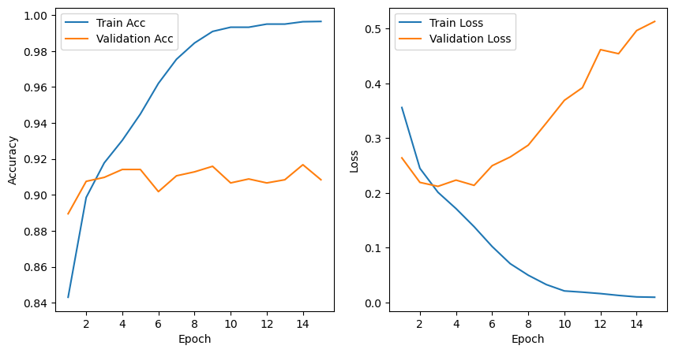

```python
trend_plot_helper(
    {
        "Accuracy - Epoch": [
            ("Train Acc", cnn_model_train_history["train_acc"]),
            ("Validation Acc", cnn_model_train_history["valid_acc"]),
        ],
        "Loss - Epoch": [
            ("Train Loss", cnn_model_train_history["train_loss"]),
            ("Validation Loss", cnn_model_train_history["valid_loss"])
        ]
    }
)
```

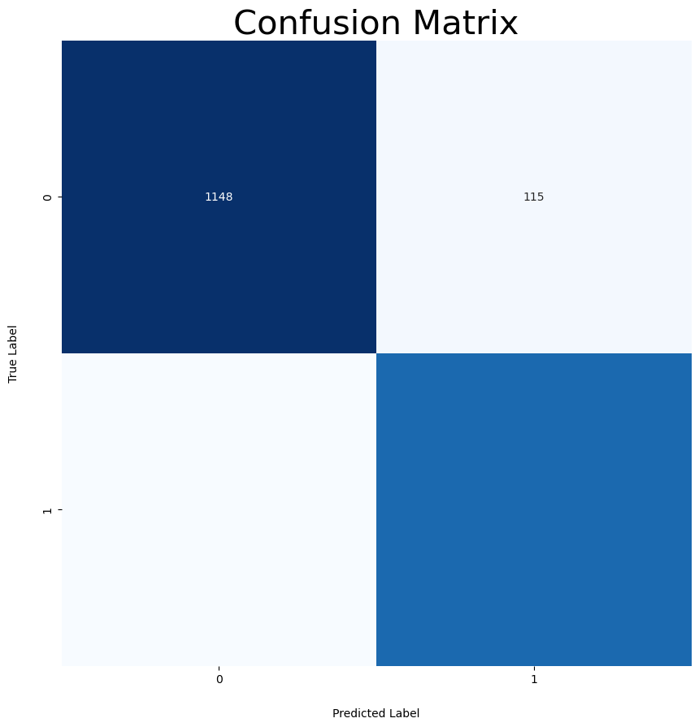

```python
cnn_model_report = generate_confusion_matrix(
    model = cnn_model,
    dataset = valid_dataset,
)
```

```python
print(f"Recall:    {cnn_model_report['recall']:.3f}")
print(f"F1:        {cnn_model_report['f1']:.3f}")
print(f"Precision: {cnn_model_report['precision']:.3f}")
print(cnn_model_report['report'])
```

```
Recall:    0.908
F1:        0.907
Precision: 0.907
              precision    recall  f1-score   support

           0       0.93      0.91      0.92      1263
           1       0.89      0.91      0.90      1008

    accuracy                           0.91      2271
   macro avg       0.91      0.91      0.91      2271
weighted avg       0.91      0.91      0.91      2271
```

```python
# TODO: create twitter dataset
train_dataset_2 = Twitter(
    dataframe = train_df,
    w2v_model = w2v_model,
    sequence_len = SEQUENCE_LEN2
)

valid_dataset_2 = Twitter(
    dataframe = valid_df,
    w2v_model = w2v_model,
    sequence_len = SEQUENCE_LEN2
)

print(f"Train dataset length: {len(train_dataset)}")
print(f"Valid dataset length: {len(valid_dataset)}")
```

```
Deleted 0-Len Samples: 22
```

```
Deleted 0-Len Samples: 9
```

```
Train dataset length: 6817
Valid dataset length: 2271
```

```python
class CNN2(nn.Module):
    def __init__(self):
        super(CNN2, self).__init__()
        self.model = nn.Sequential(
            nn.Conv1d(300, 64, kernel_size=3),
            nn.ReLU(),
            nn.Conv1d(64, 128, kernel_size=3),
            nn.ReLU(),
            nn.MaxPool1d(kernel_size=2),
            nn.Flatten(),
            nn.Linear(12288, 128),
            nn.ReLU(),
            nn.Linear(128, 2),
            nn.Sigmoid()
        )

    def forward(self, x):
        x = x.permute(0, 2, 1)
        return self.model(x)
```

```python
torch.manual_seed(42)
cnn_model_2 = CNN2()
```

```python
import torch.optim as optim
cnn_model_train_history_2 = train_model( # TODO: train your model
    model = cnn_model_2,
    batch_size = BATCH_SIZE,  # Adjust batch size as needed
    loss_function = nn.CrossEntropyLoss(),  # Choose appropriate loss function
    optimizer = optim.Adam(cnn_model_2.parameters(), lr = LEARNING_RATE),  # Adjust optimizer and learning rate as needed
    epochs = EPOCHS,  # Choose the number of epochs
    train_set = train_dataset_2,  # Provide your training dataset
    valid_set = valid_dataset_2,  # Provide your validation dataset
    device = 'cuda' if torch.cuda.is_available() else 'cpu'  # Use GPU if available, otherwise use CPU
)
```

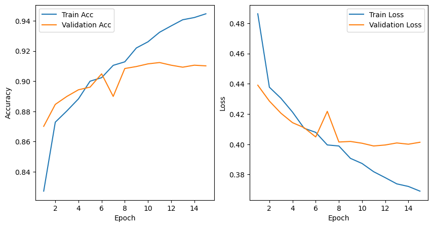

```python
trend_plot_helper(
    {
        "Accuracy - Epoch": [
            ("Train Acc", cnn_model_train_history_2["train_acc"]),
            ("Validation Acc", cnn_model_train_history_2["valid_acc"]),
        ],
        "Loss - Epoch": [
            ("Train Loss", cnn_model_train_history_2["train_loss"]),
            ("Validation Loss", cnn_model_train_history_2["valid_loss"])
        ]
    }
)
```

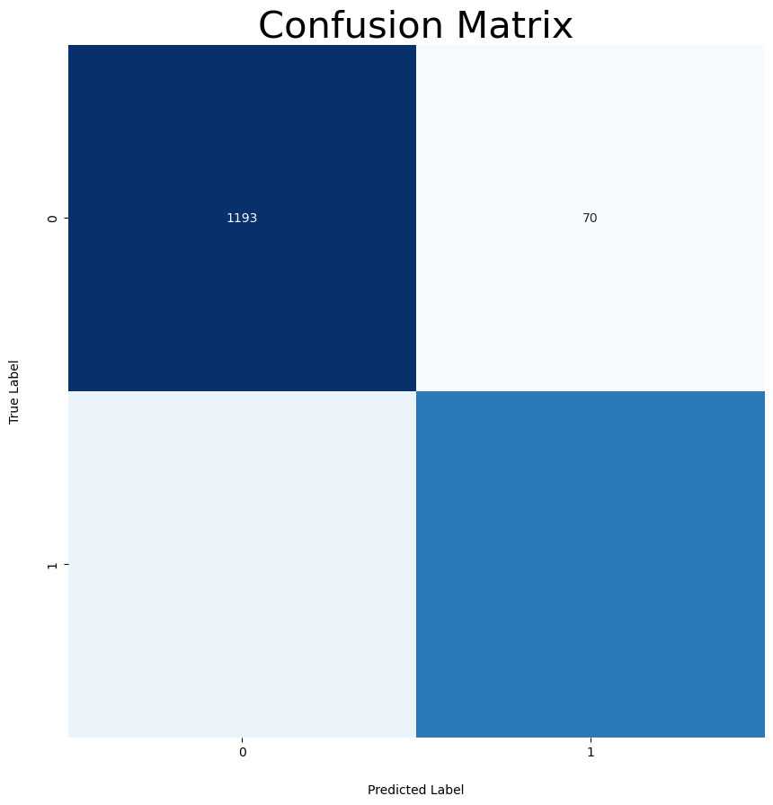

```python
cnn_model_report_2 = generate_confusion_matrix(
    model = cnn_model_2,
    dataset = valid_dataset_2,
)
```

```python
print(f"Recall:    {cnn_model_report_2['recall']:.3f}")
print(f"F1:        {cnn_model_report_2['f1']:.3f}")
print(f"Precision: {cnn_model_report_2['precision']:.3f}")
print(cnn_model_report_2['report'])
```

```
Recall:    0.906
F1:        0.908
Precision: 0.912
              precision    recall  f1-score   support

           0       0.90      0.94      0.92      1263
           1       0.93      0.87      0.90      1008

    accuracy                           0.91      2271
   macro avg       0.91      0.91      0.91      2271
weighted avg       0.91      0.91      0.91      2271
```

## Phase 4: Dropout and Normalization

```python
# TODO: create twitter dataset
train_dataset_3 = Twitter(
    dataframe = train_df,
    w2v_model = w2v_model,
    sequence_len = SEQUENCE_LEN2
)

valid_dataset_3 = Twitter(
    dataframe = valid_df,
    w2v_model = w2v_model,
    sequence_len = SEQUENCE_LEN2
)

print(f"Train dataset length: {len(train_dataset)}")
print(f"Valid dataset length: {len(valid_dataset)}")
```

```
Deleted 0-Len Samples: 22
```

```
Deleted 0-Len Samples: 9
```

```
Train dataset length: 6817
Valid dataset length: 2271
```

```python
class CNN3(nn.Module):
    def __init__(self):
        super(CNN3, self).__init__()
        self.model = nn.Sequential(
            nn.Conv1d(300, 64, kernel_size=3),
            # nn.BatchNorm1d(64),
            nn.ReLU(),
            # nn.Dropout(0.25),
            nn.Conv1d(64, 128, kernel_size=3),
            # nn.BatchNorm1d(128),
            nn.ReLU(),
            # nn.Dropout(0.75),
            nn.MaxPool1d(kernel_size=2),
            nn.Flatten(),
            nn.Linear(12288, 128),
            nn.BatchNorm1d(128),
            nn.ReLU(),
            nn.Dropout(0.25),
            nn.Linear(128, 2),
            nn.Sigmoid()
        )

    def forward(self, x):
        x = x.permute(0, 2, 1)
        return self.model(x)
```

```python
torch.manual_seed(42)
cnn_model_3 = CNN3()
```

```python
device = 'cuda' if torch.cuda.is_available() else 'cpu'
cnn_model_3.to(device)
```

```
CNN3(
  (model): Sequential(
    (0): Conv1d(300, 64, kernel_size=(3,), stride=(1,))
    (1): ReLU()
    (2): Conv1d(64, 128, kernel_size=(3,), stride=(1,))
    (3): ReLU()
    (4): MaxPool1d(kernel_size=2, stride=2, padding=0, dilation=1, ceil_mode=False)
    (5): Flatten(start_dim=1, end_dim=-1)
    (6): Linear(in_features=12288, out_features=128, bias=True)
    (7): BatchNorm1d(128, eps=1e-05, momentum=0.1, affine=True, track_running_stats=True)
    (8): ReLU()
    (9): Dropout(p=0.25, inplace=False)
    (10): Linear(in_features=128, out_features=2, bias=True)
    (11): Sigmoid()
  )
)
```

```python
import torch.optim as optim
cnn_model_train_history_3 = train_model(
    model=cnn_model_3,
    batch_size=BATCH_SIZE,
    loss_function=nn.CrossEntropyLoss(),
    optimizer=optim.Adam(cnn_model_3.parameters(), lr=LEARNING_RATE),
    epochs=EPOCHS,
    train_set=train_dataset_3,
    valid_set=valid_dataset_3,
    device='cuda' if torch.cuda.is_available() else 'cpu'
)
```

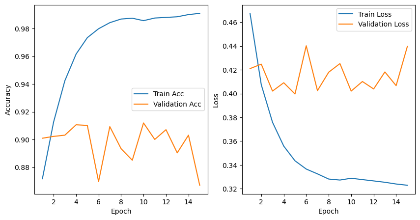

```python
trend_plot_helper(
    {
        "Accuracy - Epoch": [
            ("Train Acc", cnn_model_train_history_3["train_acc"]),
            ("Validation Acc", cnn_model_train_history_3["valid_acc"]),
        ],
        "Loss - Epoch": [
            ("Train Loss", cnn_model_train_history_3["train_loss"]),
            ("Validation Loss", cnn_model_train_history_3["valid_loss"])
        ]
    }
)
```

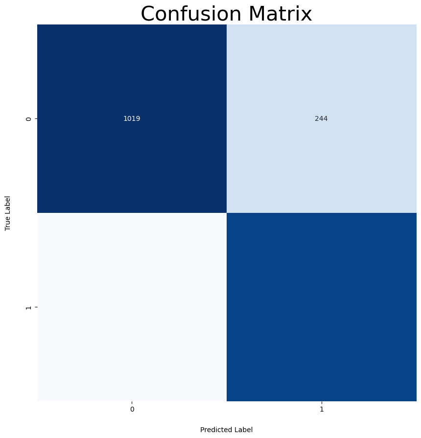

```python
cnn_model_report_3 = generate_confusion_matrix(
    model = cnn_model_3,
    dataset = valid_dataset_3,
)
```

```python
print(f"Recall:    {cnn_model_report_3['recall']:.3f}")
print(f"F1:        {cnn_model_report_3['f1']:.3f}")
print(f"Precision: {cnn_model_report_3['precision']:.3f}")
print(cnn_model_report_3['report'])
```

```
Recall:    0.875
F1:        0.867
Precision: 0.871
              precision    recall  f1-score   support

           0       0.95      0.81      0.87      1263
           1       0.80      0.94      0.86      1008

    accuracy                           0.87      2271
   macro avg       0.87      0.87      0.87      2271
weighted avg       0.88      0.87      0.87      2271
```

### Overall Comparison:

The loss function in part 1 with sequence length being 64 is quite low and throughout all the epochs, it was dicreased and almost approximated to 0. The loss function in part 2 with sequence length being 196 and in part 3, was generally more in scale. But the accuracies in these 3 parts do not vary that much, though if we want to compare, the f1 score in part 3 is lower than the other 2. The other significant aspect of the 3rd part was the way that the model performed on the test set. It was not overall bad, but the performance on the test set had significant ups and downs, as you can see in the plots.

In the 2nd part, the test accuracy and the train accuracy converge closer to each other, in comparison to the first part.